# House Prices Analysis

xipecast

2026

## Overview

Analysis of **1,460 house sales** in Ames, Iowa (2006-2010). Goal: Identify key factors that drive house sale prices.

- **Rows**: 1,460 houses
- **Columns**: 81 variables (cleaned to 78)
- **Target**: Sale Price (USD)

## 1. Sale Price Distribution

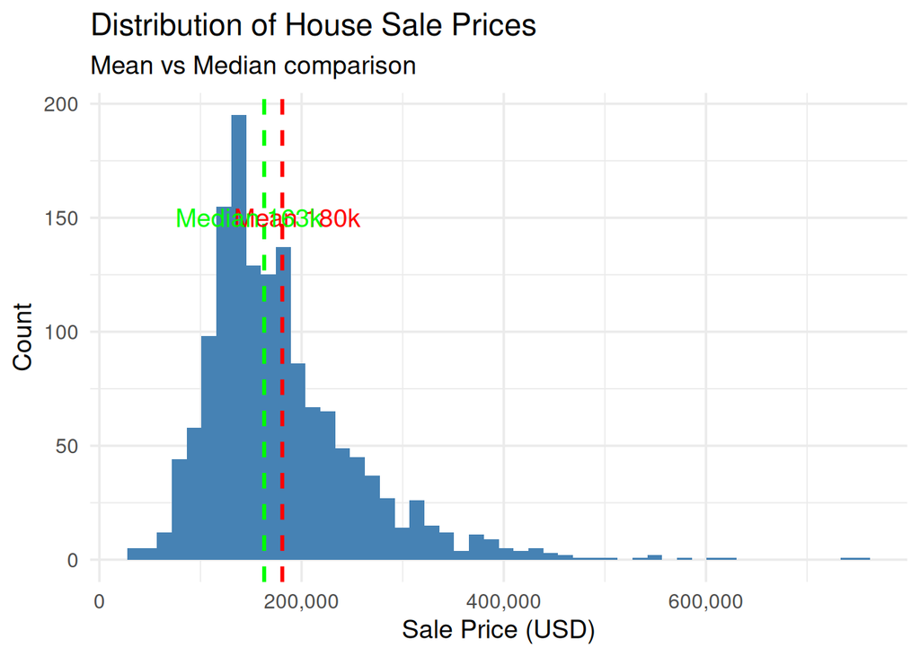

```r
ggplot(houses, aes(x = SalePrice)) +
  geom_histogram(bins = 50, fill = "steelblue") +
  geom_vline(aes(xintercept = mean(SalePrice)),
             color = "red", linetype = "dashed", linewidth = 1) +
  geom_vline(aes(xintercept = median(SalePrice)),
             color = "green", linetype = "dashed", linewidth = 1) +
  annotate("text", x = mean(houses$SalePrice) + 15000, y = 150,
           label = "Mean 180k", color = "red") +
  annotate("text", x = median(houses$SalePrice) - 15000, y = 150,
           label = "Median 163k", color = "green") +
  scale_x_continuous(labels = scales::comma) +
  labs(title = "Distribution of House Sale Prices",
       subtitle = "Mean vs Median comparison",
       x = "Sale Price (USD)", y = "Count")
```

### Finding

```r
houses %>%
  summarise(
    Mean = scales::comma(round(mean(SalePrice))),
    Median = scales::comma(median(SalePrice)),
    Min = scales::comma(min(SalePrice)),
    Max = scales::comma(max(SalePrice))
  )
```

```
## # A tibble: 1 × 4
##   Mean    Median  Min    Max
##   <chr>   <chr>   <chr>  <chr>
## 1 180,921 163,000 34,900 755,000
```

> Price distribution is **right skewed**—mean ($180k) pulled above median ($163k) by luxury outliers. Median is the better representation of typical house price.

## 2. Price Clusters

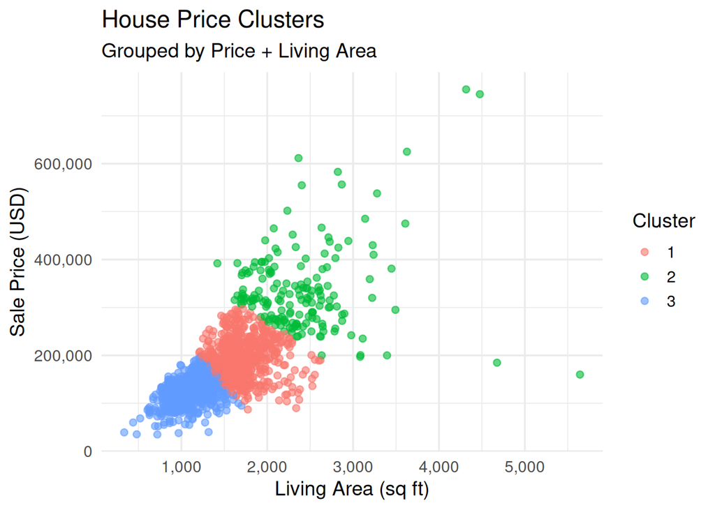

```r
set.seed(42)
clusters <- kmeans(scale(houses[, c("SalePrice", "GrLivArea")]), centers = 3)
houses$cluster <- as.factor(clusters$cluster)

ggplot(houses, aes(x = GrLivArea, y = SalePrice, color = cluster)) +
  geom_point(alpha = 0.6) +
  scale_y_continuous(labels = scales::comma) +
  scale_x_continuous(labels = scales::comma) +
  labs(title = "House Price Clusters",
       subtitle = "Grouped by Price + Living Area",
       x = "Living Area (sq ft)", y = "Sale Price (USD)", color = "Cluster")
```

> Three natural price clusters emerge. Notable outlier: small high-quality house in Stone Brook neighborhood commands $392k despite 1,419 sq ft—location and quality trump size.

## 3. Neighborhood Analysis

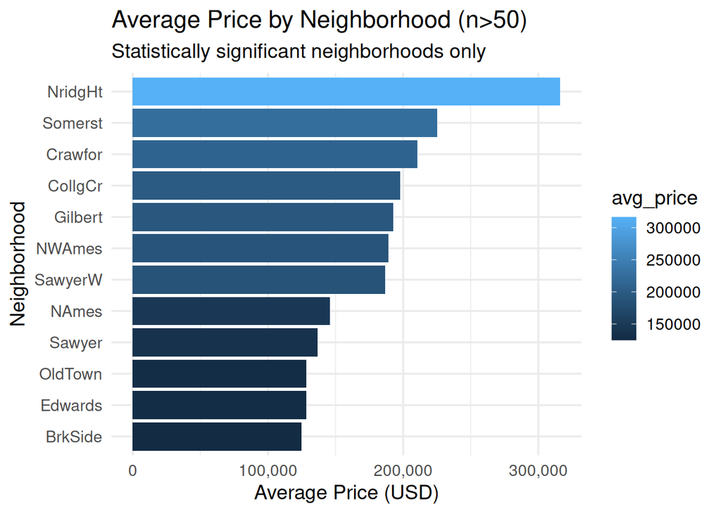

```r
houses %>%
  group_by(Neighborhood) %>%
  summarise(avg_price = mean(SalePrice), count = n()) %>%
  filter(count > 50) %>%
  ggplot(aes(x = reorder(Neighborhood, avg_price),
             y = avg_price, fill = avg_price)) +
  geom_col() +
  scale_y_continuous(labels = scales::comma) +
  coord_flip() +
  labs(title = "Average Price by Neighborhood (n>50)",
       subtitle = "Statistically significant neighborhoods only",
       x = "Neighborhood", y = "Average Price (USD)")
```

## 4. Quality vs Price

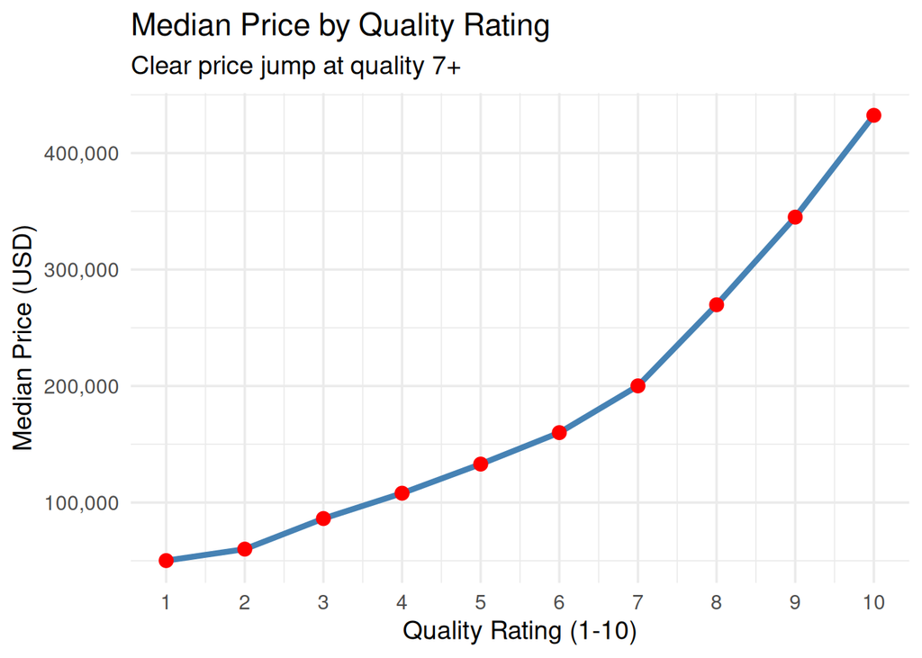

```r
houses %>%
  group_by(OverallQual) %>%
  summarise(median_price = median(SalePrice)) %>%
  ggplot(aes(x = OverallQual, y = median_price)) +
  geom_line(color = "steelblue", linewidth = 1.5) +
  geom_point(size = 3, color = "red") +
  scale_y_continuous(labels = scales::comma) +
  scale_x_continuous(breaks = 1:10) +
  labs(title = "Median Price by Quality Rating",
       subtitle = "Clear price jump at quality 7+",
       x = "Quality Rating (1-10)", y = "Median Price (USD)")
```

> **Quality 7 = luxury threshold.** Price slope steepens dramatically at rating 7+. Sellers should target renovations that push quality from 6 to 7 for maximum ROI.

## 5. Year Built vs Price

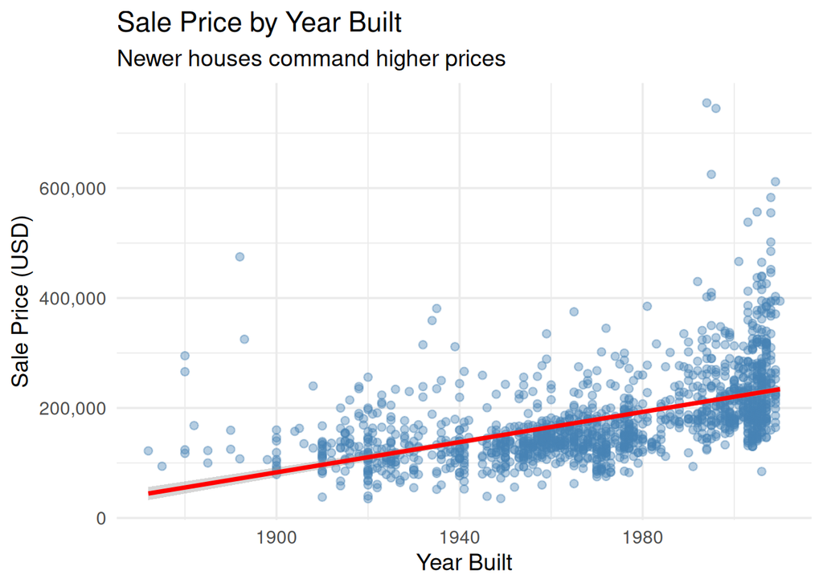

```r
ggplot(houses, aes(x = YearBuilt, y = SalePrice)) +
  geom_point(alpha = 0.4, color = "steelblue") +
  geom_smooth(method = "lm", color = "red") +
  scale_y_continuous(labels = scales::comma) +
  labs(title = "Sale Price by Year Built",
       subtitle = "Newer houses command higher prices",
       x = "Year Built", y = "Sale Price (USD)")
```

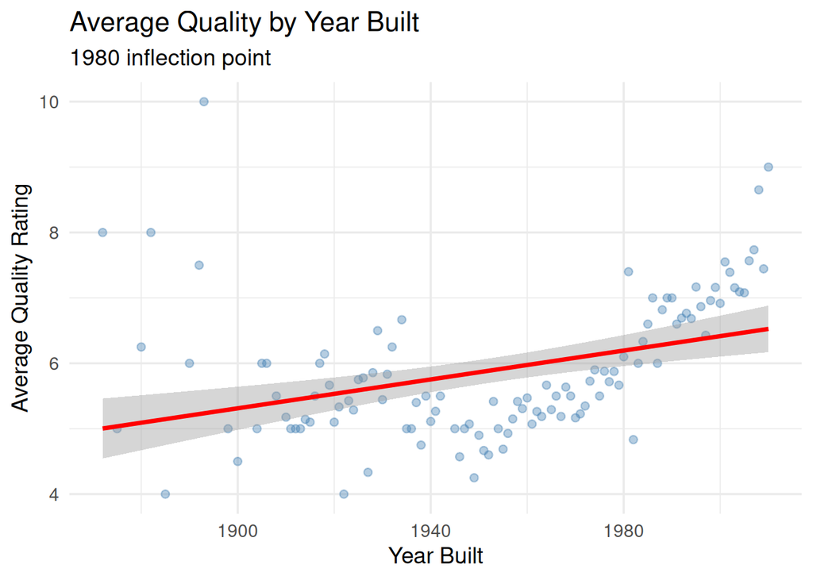

```r
houses %>%
  group_by(YearBuilt) %>%
  summarise(avg_quality = mean(OverallQual)) %>%
  ggplot(aes(x = YearBuilt, y = avg_quality)) +
  geom_point(alpha = 0.4, color = "steelblue") +
  geom_smooth(method = "lm", color = "red") +
  labs(title = "Average Quality by Year Built",
       subtitle = "1980 inflection point",
       x = "Year Built", y = "Average Quality Rating")
```

> **1980 = construction quality inflection point.** Post-1980 houses show consistently higher quality ratings AND prices. Older houses are cheaper primarily due to lower quality—not age alone.

## 6. Garage Size vs Price

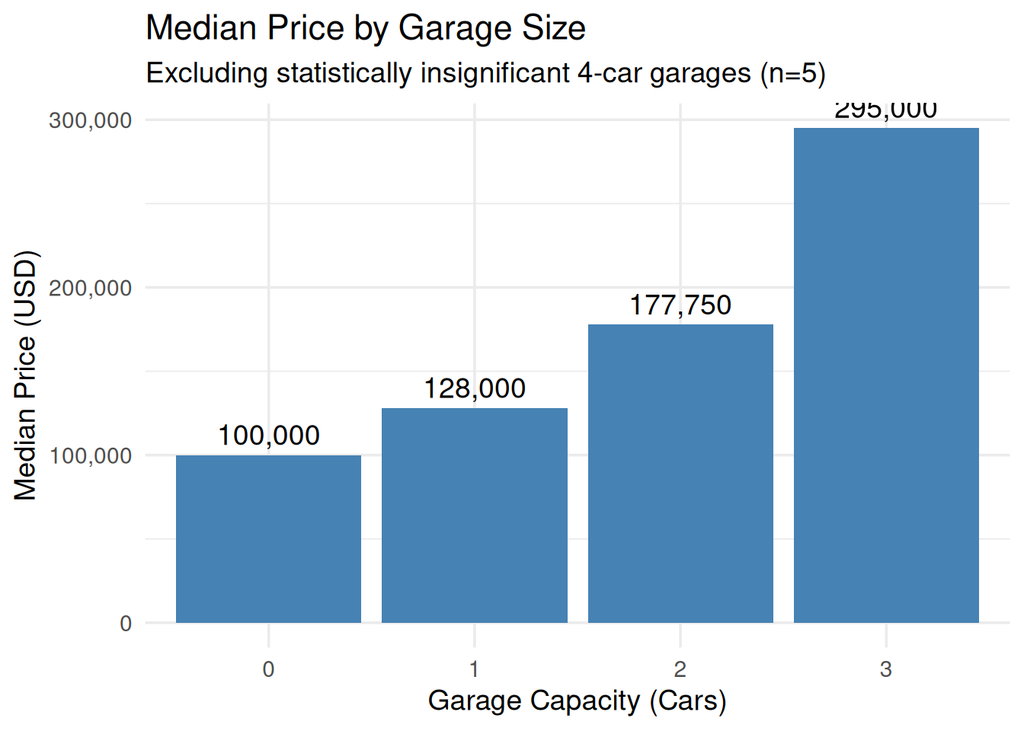

```r
houses_clean %>%
  filter(GarageCars <= 3) %>%
  group_by(GarageCars) %>%
  summarise(median_price = median(SalePrice)) %>%
  ggplot(aes(x = factor(GarageCars), y = median_price)) +
  geom_col(fill = "steelblue") +
  scale_y_continuous(labels = scales::comma) +
  geom_text(aes(label = scales::comma(round(median_price))), vjust = -0.5) +
  labs(title = "Median Price by Garage Size",
       subtitle = "Excluding statistically insignificant 4-car garages (n=5)",
       x = "Garage Capacity (Cars)", y = "Median Price (USD)")
```

> Each additional garage space adds significant value. **2→3 car jump adds $117,250** to median price. 4-car garage data excluded (n=5, statistically insignificant).

## 7. Living Area vs Price

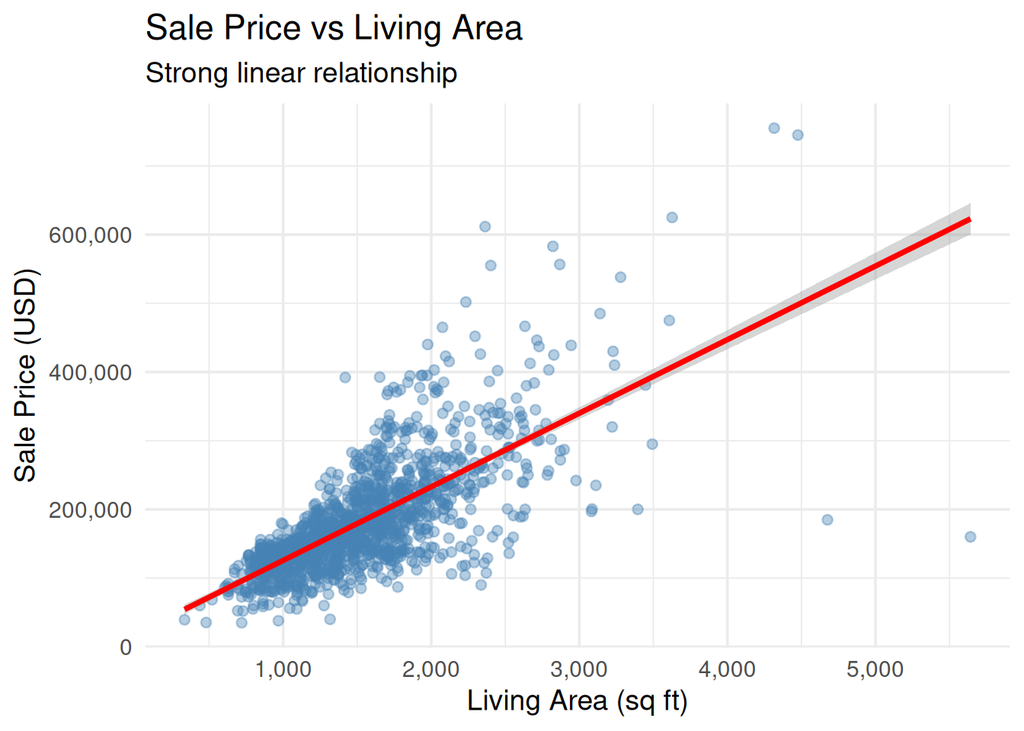

```r
ggplot(houses_clean, aes(x = GrLivArea, y = SalePrice)) +
  geom_point(alpha = 0.4, color = "steelblue") +
  geom_smooth(method = "lm", color = "red") +
  scale_y_continuous(labels = scales::comma) +
  scale_x_continuous(labels = scales::comma) +
  labs(title = "Sale Price vs Living Area",
       subtitle = "Strong linear relationship",
       x = "Living Area (sq ft)", y = "Sale Price (USD)")
```

> **Size matters**—strong positive linear relationship between living area and price. Most homes cluster between 1,000-2,500 sq ft.

## Key Findings

[output not shown]